# Criação de gráficos com o ggplot2

# **Gráfico de histogramas**

O histograma é uma representação gráfica da distribuição de um conjunto de dados numéricos. Ele é usado para visualizar a frequência com que diferentes intervalos de valores ocorrem em um conjunto de dados.

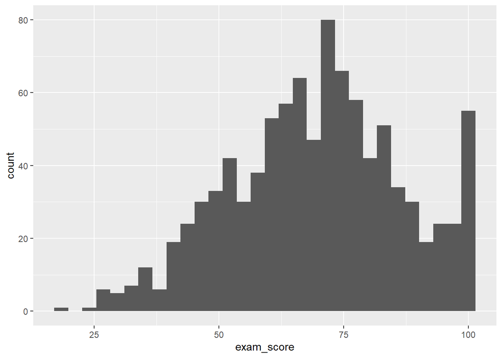

```r
performance %>%
    ggplot(aes(x = exam_score)) + geom_histogram()  # por default, o geom_histogram() apresenta 30 classes(bins)
```

As modificações de cores são feitas da mesma forma que no gráfico de barras. Para modificar as classes, podemos utilizar os seguintes argumentos dentro do `geom_histogram`

- `bins` para alterar quantidade de classes
- `binwidth` para alterar a amplitude de todas as classes
- `breaks` para definir intervalos com amplitudes diferentes

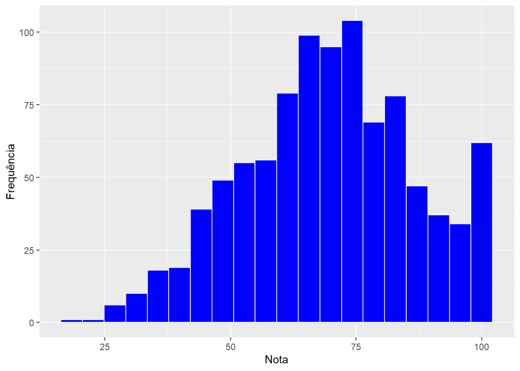

```r
# bins
performance %>%
    ggplot(aes(x = exam_score)) + geom_histogram(fill = "blue", color = "white",
    bins = 20) + labs(x = "Nota", y = "Frequência")
```

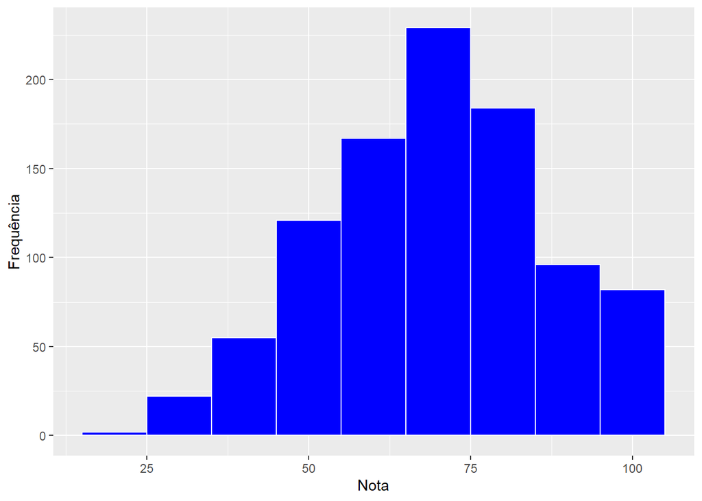

```r
# binwidth
performance %>%
    ggplot(aes(x = exam_score)) + geom_histogram(fill = "blue", color = "white",
    binwidth = 10) + labs(x = "Nota", y = "Frequência")
```

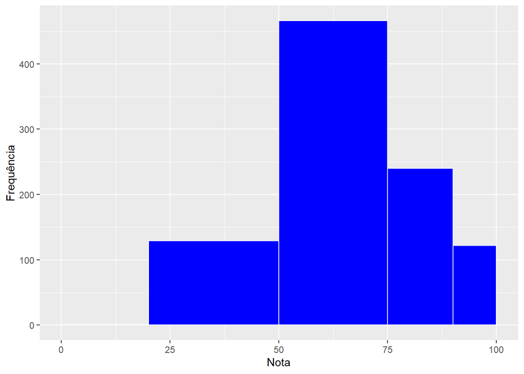

```r
# breaks
performance %>%
    ggplot(aes(x = exam_score)) + geom_histogram(fill = "blue", color = "white",
    breaks = c(0, 20, 50, 75, 90, 100)) + labs(x = "Nota", y = "Frequência")
```

# **Boxplot**

O boxplot é uma representação usada para verificar a distribuição de uma variável por meio de seus quantis. Esse gráfico permite verificar os valores de mínimo, máximo e os quartis. Além disso, indica a existência de valores discrepantes (outliers).

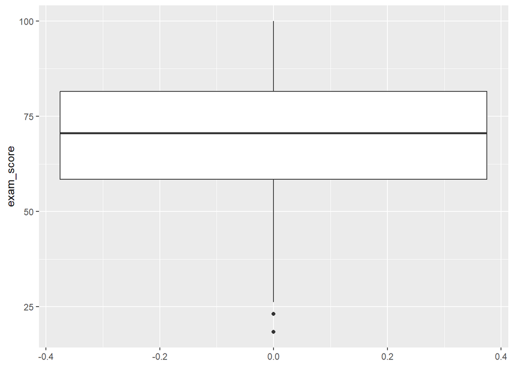

```r
performance %>%
    ggplot(aes(y = exam_score)) + geom_boxplot()
```

Para adicionar os limites (representados pelos bigodes) no gráfico de boxplot, utilizamos a função `geom_errorbar`.

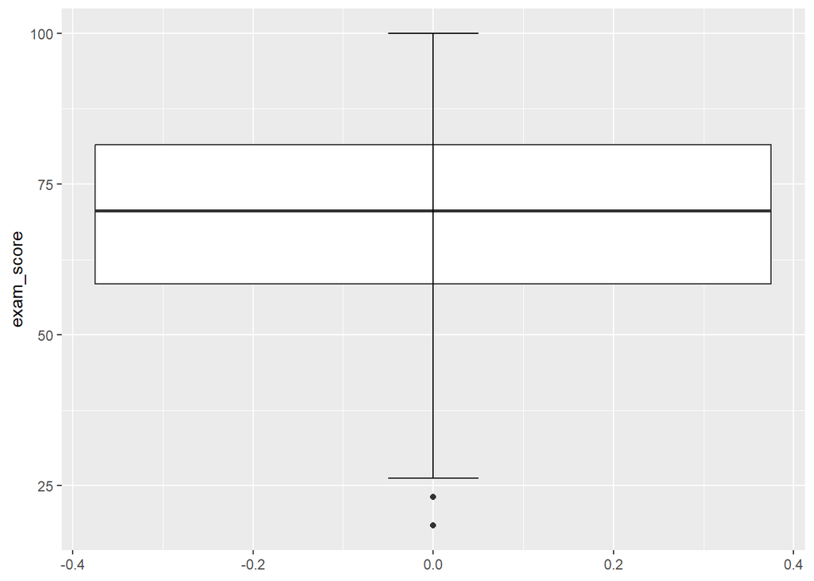

```r
performance %>%
  ggplot(aes(y = exam_score))+
  geom_boxplot()+
  geom_errorbar(stat='boxplot', # definição necessária para a função entender quais são os limites
                width = 0.1) # alterando o tamanho dos bigodes
```

É possível modificar a cor do boxplot usando `fill` e `color` , modificar outliersm(inclusive removê-los do gráfico) utilizando o argumento `outlier.shape`.

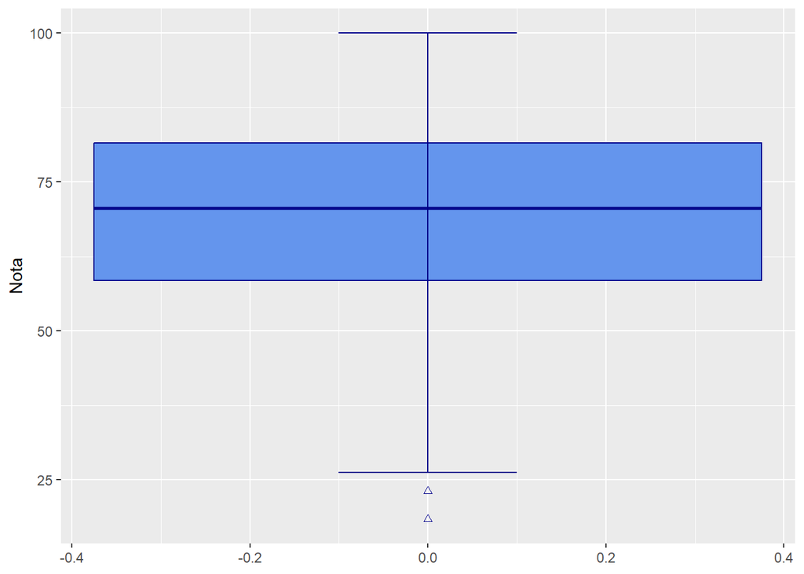

```r
# modificando a forma dos outliers
performance %>%
    ggplot(aes(y = exam_score)) + geom_boxplot(fill = "cornflowerblue", color = "darkblue",
    outlier.shape = 2) + geom_errorbar(stat = "boxplot", width = 0.2, color = "darkblue") +
    labs(y = "Nota")
```

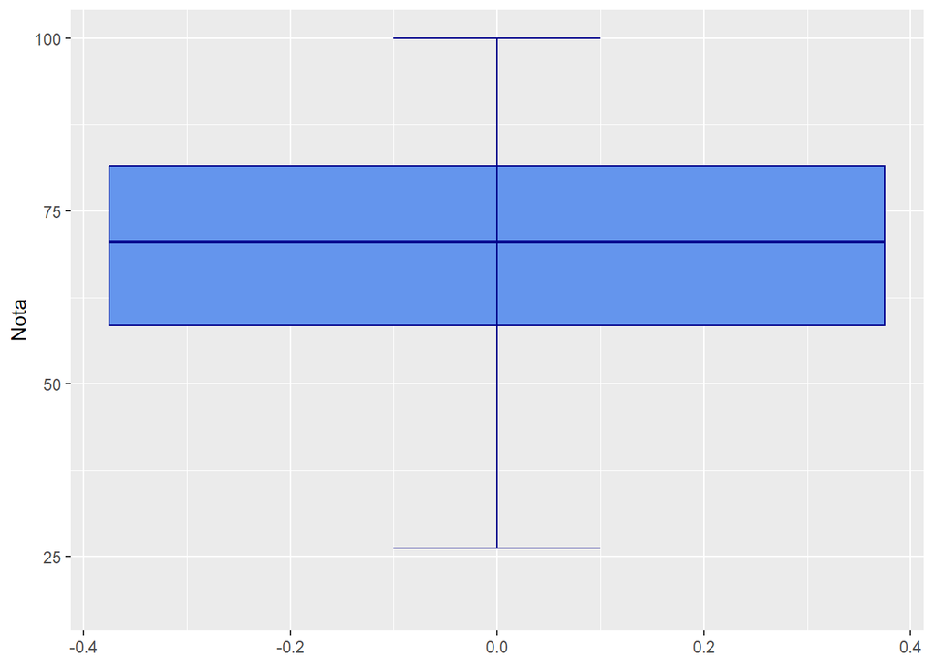

```r
# removendo os outliers
performance %>%
    ggplot(aes(y = exam_score)) + geom_boxplot(fill = "cornflowerblue", color = "darkblue",
    outlier.shape = NA) + geom_errorbar(stat = "boxplot", width = 0.2, color = "darkblue") +
    labs(y = "Nota")
```

Assim como nos gráficos anteriores, é possível criar boxplots para cada categoria de uma variável categórica, especificando-a no **mapping**

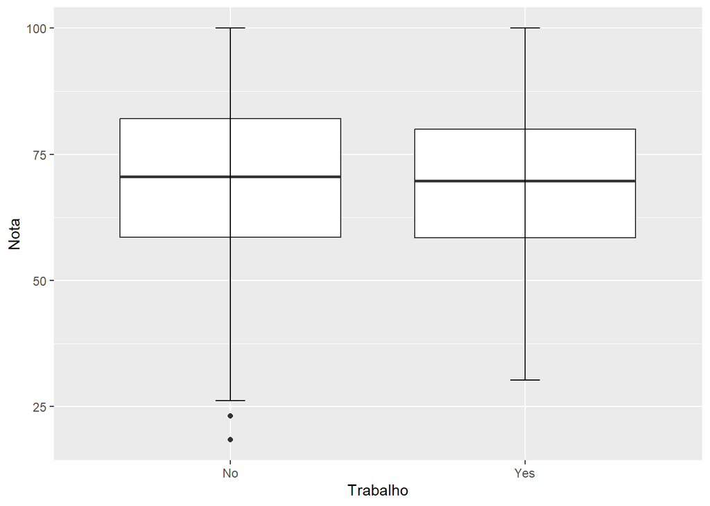

```r
# distribuição da nota de acordo com a variável part_time_job
performance %>%
  ggplot(aes(x = part_time_job,y = exam_score))+
  geom_boxplot()+
  geom_errorbar(stat='boxplot',
                width=0.1)+
  labs(x = "Trabalho",
       y = "Nota",
       fill='Sexo')
```

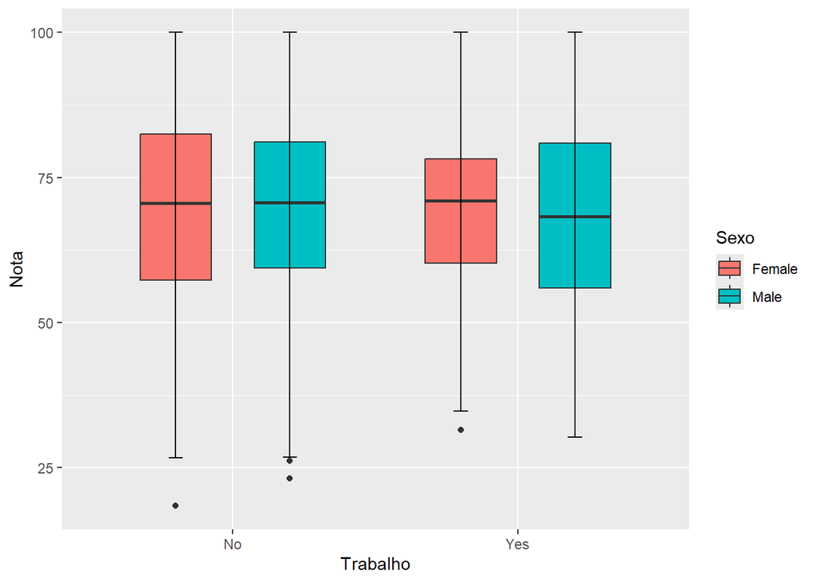

```r
# distribuição da nota de acordo com a variável part_time_job e gender
performance %>%
  ggplot(aes(x = part_time_job,y = exam_score,fill=gender))+
  geom_boxplot(position = position_dodge(width=0.8), # alterando a proximdade entre as caixas
               width = 0.5)+ #alterando o tamanho da caixa
  geom_errorbar(stat='boxplot',
                width=0.1,
                position = position_dodge(width=0.8))+ # alterando a posição das barras de erro (utilizar o mesmo argumento position do geom_boxplot para o alinhamento)
  labs(x = "Trabalho",
       y = "Nota",
       fill='Sexo')
```

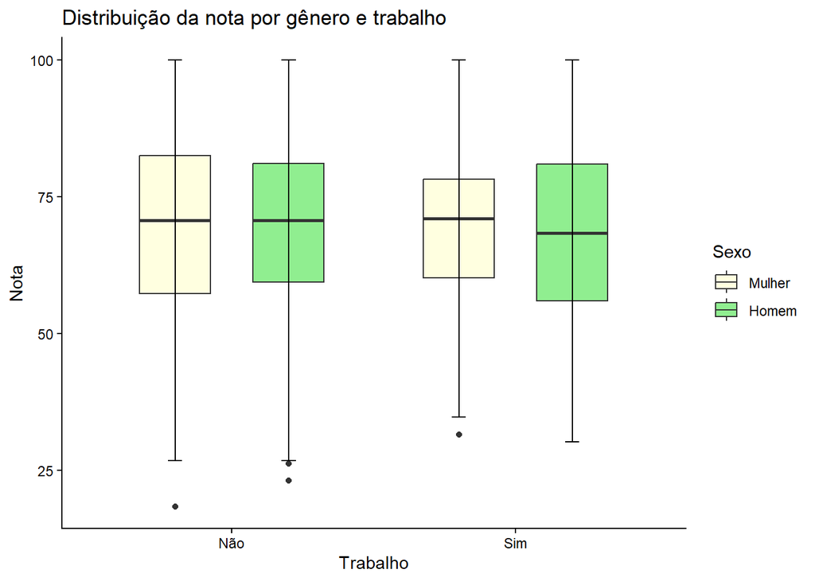

```r
performance %>%
    ggplot(aes(x = part_time_job, y = exam_score, fill = gender)) + geom_boxplot(position = position_dodge(width = 0.8),
    width = 0.5) + geom_errorbar(stat = "boxplot", width = 0.1, position = position_dodge(width = 0.8)) +
    scale_fill_manual(breaks = c("Female", "Male"), labels = c("Mulher", "Homem"),
        values = c("lightyellow", "lightgreen")) + scale_x_discrete(labels = c("Não",
    "Sim")) + labs(title = "Distribuição da nota por gênero e trabalho", x = "Trabalho",
    y = "Nota", fill = "Sexo") + theme_classic()
```

# **Gráfico de densidade**

Outra forma de representar a ditribuição de uma variável quantitativa, é utilizando gráfico de densidade usando o `geom_density`

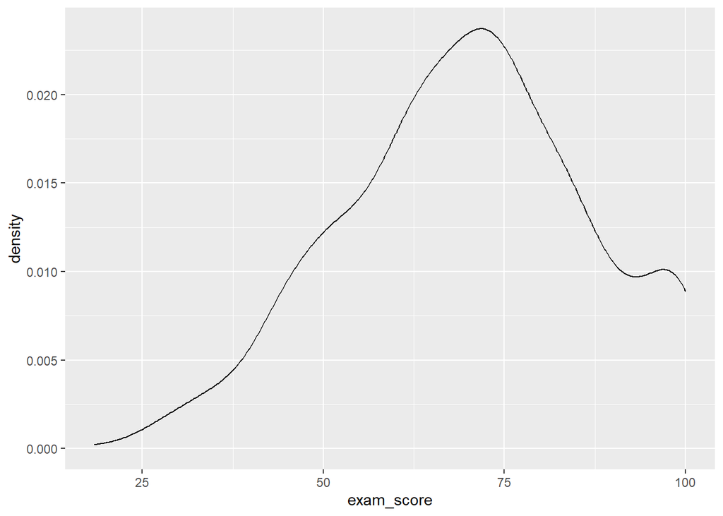

```r
performance %>%
    ggplot(aes(x = exam_score)) + geom_density()
```

Para comparar distribuições entre as categorias de uma variável qualitativa, precisamos mapear dentro do `mapping = aes()`.

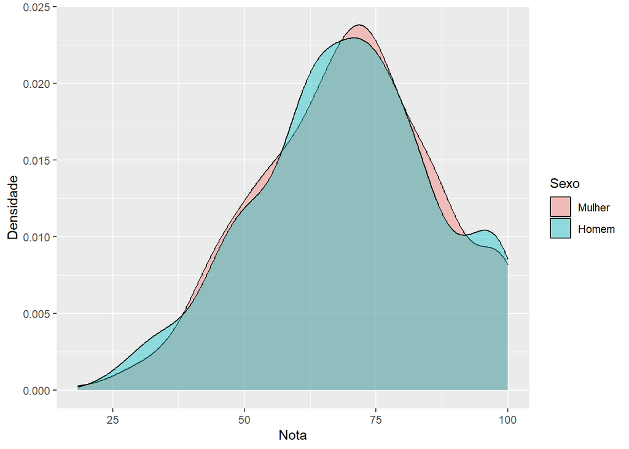

```r
performance %>%
  ggplot(aes(x = exam_score,fill = gender))+
  geom_density(alpha = 0.4)+ # alterando a opacidade
  scale_fill_discrete(labels = c("Mulher","Homem"))+
  labs(x = 'Nota',
       y = 'Densidade',
       fill = 'Sexo')
```

# **Gráfico de Violino**

Os gráficos de violinos também mostram a distribuição de uma variável quantitativa e é semelhante ao gráfico de densidade, porém ambos argumentos `x` e `y` são obrigatórios. Sua plotagem é espelhada e rotacionada em 90 graus.

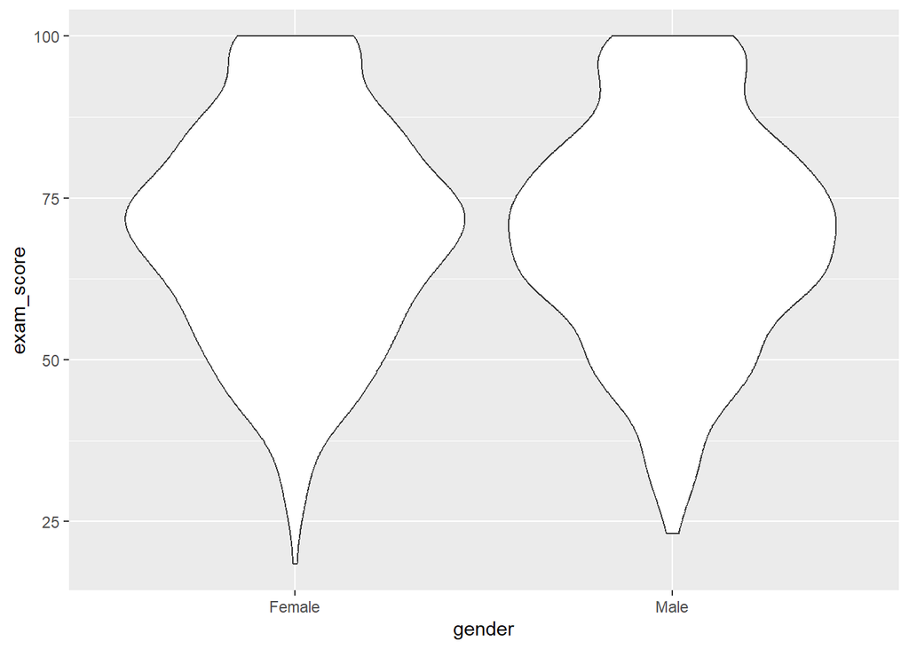

```r
# violino
performance %>%
    ggplot(aes(x = gender, y = exam_score)) + geom_violin()
```

Podemos combinar boxplots e os violinos.

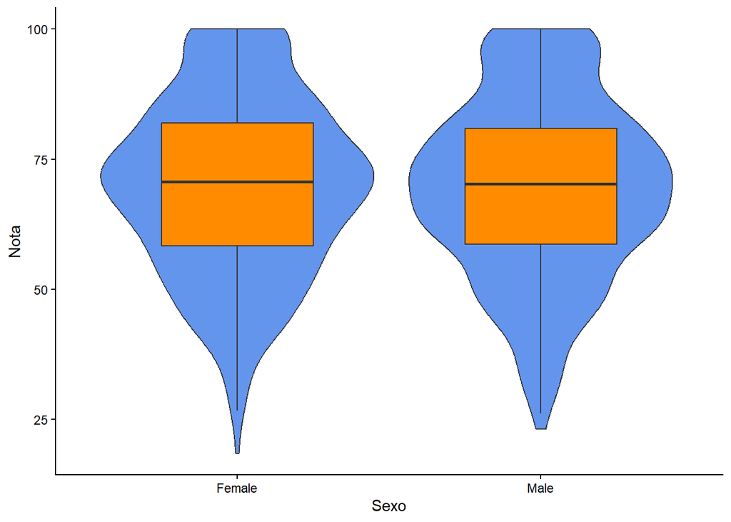

```r
performance %>%
  ggplot(aes(x = gender,y = exam_score))+
  geom_violin(fill='cornflowerblue')+
  geom_boxplot(fill='darkorange',
               width = 0.5, # alterando o tamanho da caixa para o boxplot ficar dentro do violino
               outlier.shape = NA)+
  scale_x_discrete()+
  labs(x = 'Sexo',
       y = 'Nota')+
  theme_classic()
```

# **Séries Temporais**

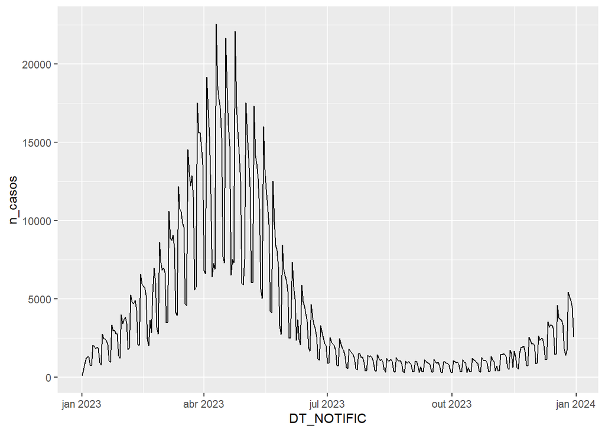

```r
casos_data = dados %>%
    group_by(DT_NOTIFIC) %>%
    summarize(n_casos = n())

casos_data %>%
    ggplot(aes(x = DT_NOTIFIC, y = n_casos)) + geom_line()
```

### **Formatando eixos com datas**

Os eixos com as datas são formatadas pelas funções `scale_x_date` e `scale_y_date`. Os principais argumentos dessas funções são:

- `date_breaks` para indicar as quebras no eixo
- `date_labels` para indicar a formatação dos rótulos

Códigos de formatação de datas em R

| Código | Significado | Exemplo |
| --- | --- | --- |
| %a | Dia da semana (abreviado) | “Dom” |
| %A | Dia da semana (completo) | “Domingo” |
| %e | Dia do mês (sem zero) | “2” |
| %d | Dia do mês (com zero) | “02” |
| %m | Mês (numérico, com zero) | “12” |
| %b | Mês (abreviado) | “Dez” |
| %B | Mês (completo) | “Dezembro” |
| %y | Ano (sem século) | “23” |
| %Y | Ano (com século) | “2023” |

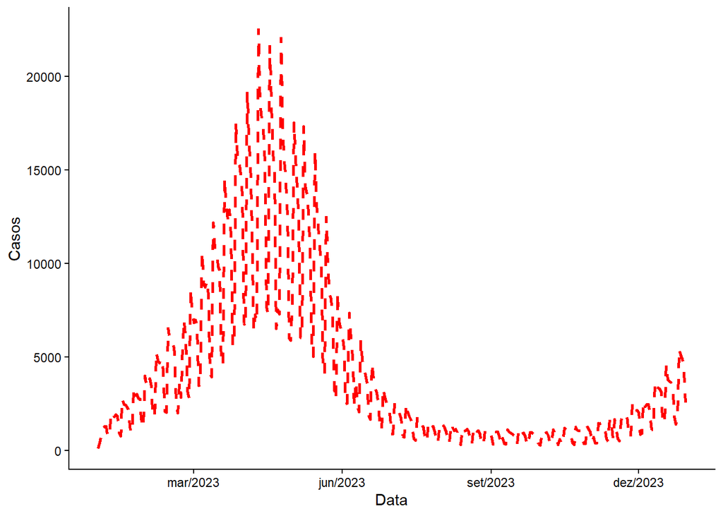

```r
casos_data %>% ggplot(aes(x = DT_NOTIFIC,y = n_casos))+
  geom_line(col='red',
            linewidth=1, # alterando a grossura da linha
            linetype = 'dashed')+ # alterando o tipo da linha
  scale_x_date(date_breaks = '3 month',
               date_labels = '%b/%Y')+
  labs(x = 'Data',
       y = 'Casos')+
  theme_classic()
```

Para fazer gráfico de linha por categorias de uma variável qualitativa, especificamos a informação no **mapping**

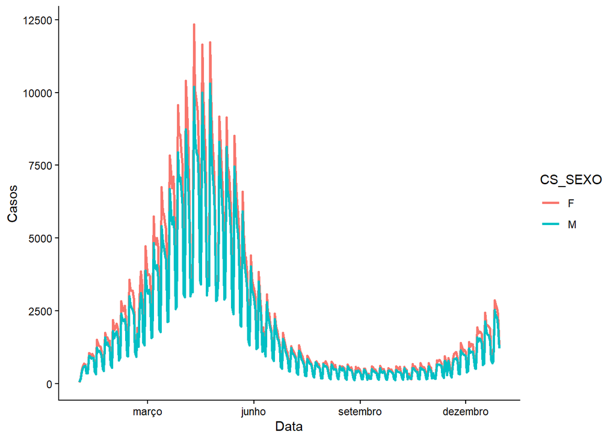

```r
casos_data_sexo = dados %>%
    filter(CS_SEXO %in% c("F", "M")) %>%
    group_by(DT_NOTIFIC, CS_SEXO) %>%
    summarize(n_casos = n())

casos_data_sexo %>%
    ggplot(aes(x = DT_NOTIFIC, y = n_casos, color = CS_SEXO)) + geom_line(linewidth = 1) +
    scale_x_date(date_breaks = "3 month", date_labels = "%B") + labs(x = "Data",
    y = "Casos") + theme_classic()
```

Supondo que estamos interessados em observar a evolução no número de casos por sexo e região. Podemos reproduzir o gráfico acima para todas as regiões do Brasil usando o `facet_wrap`.

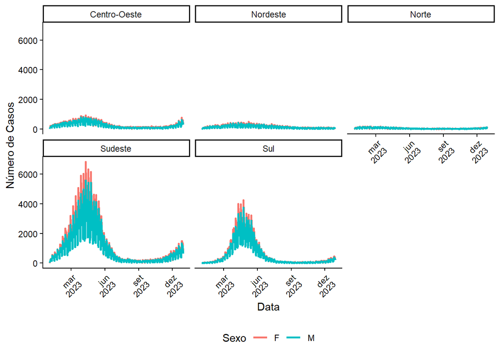

```r
# Agrupando os dados pela data, sexo e região
casos_regiao = dados %>%
  filter(CS_SEXO %in% c('F','M')) %>%
  group_by(DT_NOTIFIC, CS_SEXO, REGIAO) %>%
  summarize(n_casos = n())

# plotando
casos_regiao %>%
  ggplot(aes(x = DT_NOTIFIC, y = n_casos, color = CS_SEXO)) +
  geom_line(linewidth = 1) +
  facet_wrap(~REGIAO) +
  scale_x_date(
    date_breaks = "3 months",
    date_labels = "%b\n%Y" ) + # o \n é utilizado para quebra de linha
  labs(x = "Data",
       y = "Número de Casos",
       color = "Sexo") +
  theme_classic() +
  theme(axis.text.x = element_text(angle = 45, hjust = 1),
    legend.position = "bottom")
```